# Week 4 Advanced Arima modeling (Arpan Pradhan)

Part 1. 10 pts - Exploratory Data Analysis

10 pts Complete a quantitative and qualitative data exploration. Include a verbal summary of your EDA.

```python
import pandas as pd
data = pd.read_csv('hw4_data.csv')

# Displaying the first few rows
data.head()
```

|  | ds | co2 |
| --- | --- | --- |
| 0 | 1958-03-15 | 315.700 |
| 1 | 1958-04-15 | 317.450 |
| 2 | 1958-05-15 | 317.510 |
| 3 | 1958-06-15 | 316.685 |
| 4 | 1958-07-15 | 315.860 |

## Quantitative data exploration

```python
# Summary statistics for the 'co2' column
summary_statistics = data['co2'].describe()
summary_statistics
```

```
count    735.000000
mean     354.210673
std       27.922811
min      313.200000
25%      328.785000
50%      351.340000
75%      376.515000
max      414.830000
Name: co2, dtype: float64
```

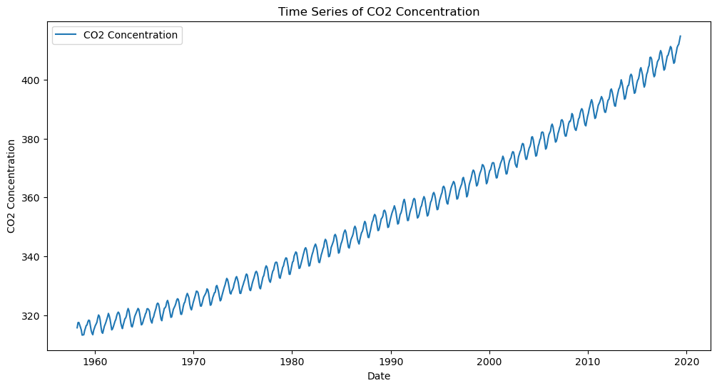

```python
import matplotlib.pyplot as plt
# Converting 'ds' to datetime and set it as the index
data['ds'] = pd.to_datetime(data['ds'])
data.set_index('ds', inplace=True)

# Plotting the time series
plt.figure(figsize=(12, 6))
plt.plot(data.index, data['co2'], label='CO2 Concentration')
plt.xlabel('Date')
plt.ylabel('CO2 Concentration')
plt.title('Time Series of CO2 Concentration')
plt.legend()
plt.show()
```

```python
from statsmodels.tsa.stattools import adfuller

# Perform the ADF test
adf_result = adfuller(data['co2'])

# Extract and display the results
adf_output = pd.Series(adf_result[0:4], index=['ADF Statistic', 'p-value', '# Lags Used', '# Observations'])
adf_output
```

```
ADF Statistic       5.242612
p-value             1.000000
# Lags Used        20.000000
# Observations    714.000000
dtype: float64
```

```python
# Applying first-order differencing
data['co2_diff'] = data['co2'].diff().dropna()

#  ADF test on differenced data
adf_result_diff = adfuller(data['co2_diff'].dropna())
adf_output_diff = pd.Series(adf_result_diff[0:4], index=['ADF Statistic', 'p-value', '# Lags Used', '# Observations'])
adf_output_diff
```

```
ADF Statistic      -4.689256
p-value             0.000088
# Lags Used        20.000000
# Observations    713.000000
dtype: float64
```

## Qualitative

Trend analysis : The time series plot reveals a clear upward trend in CO2 concentration over time, indicating that CO2 levels have been increasing steadily.

Seasonality: There are visible seasonal patterns in the data, with CO2 levels peaking at certain times of the year and dipping at others, suggesting a yearly seasonal cycle.

Anomalies : No significant anomalies or outliers were noted in the data plot, indicating consistent measurements over time.

The dataset consisted of monthly CO2 concentration measurements from March 1958 to the most recent date. The data shows a clear upward trend in CO2 levels, indicating a steady increase over time. There is also a noticeable seasonal pattern, suggesting a recurring yearly cycle in CO2 concentrations. Summary statistics reveal that the average CO2 concentration over the period is 354.21 ppm, with a standard deviation of 27.92 ppm. The data ranges from a minimum of 313.20 ppm to a maximum of 414.83 ppm. The Augmented Dickey-Fuller test confirms that the original series is non-stationary, but it becomes stationary after first-order differencing. No significant anomalies or outliers were observed.

Part 2. 30 pts – Seasonal ARIMA – need to use statsmodels in order to examine residuals

2A) 6 pts Determine the seasonal differencing order, use y_train. Include the following: plot of differenced data, ADF results, kpss results

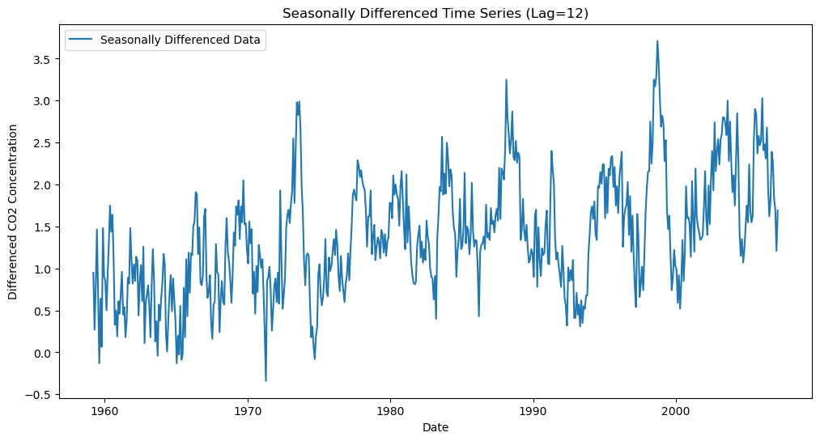

```
(ADF Statistic      -4.059281
 p-value             0.001130
 # Lags Used        13.000000
 # Observations    562.000000
 dtype: float64,
 KPSS Statistic     1.675362
 p-value            0.010000
 Lags Used         15.000000
 dtype: float64)
```

```python
from statsmodels.tsa.seasonal import seasonal_decompose
from statsmodels.tsa.stattools import kpss
import warnings
warnings.filterwarnings('ignore')
# Splitting into training and test sets
train_size = int(len(data) * 0.8)
train, test = data.iloc[:train_size], data.iloc[train_size:]

# Performing seasonal differencing ,period of 12 months
seasonal_diff = train['co2'].diff(12).dropna()

# Plotting the seasonally differenced data
plt.figure(figsize=(12, 6))
plt.plot(seasonal_diff, label='Seasonally Differenced Data')
plt.xlabel('Date')
plt.ylabel('Differenced CO2 Concentration')
plt.title('Seasonally Differenced Time Series (Lag=12)')
plt.legend()
plt.show()

# Performing ADF test on seasonally differenced data
adf_result_seasonal = adfuller(seasonal_diff)
adf_output_seasonal = pd.Series(adf_result_seasonal[0:4], index=['ADF Statistic', 'p-value', '# Lags Used', '# Observations'])

# Performing KPSS test on seasonally differenced data
kpss_result_seasonal = kpss(seasonal_diff, regression='c', nlags='auto')
kpss_output_seasonal = pd.Series(kpss_result_seasonal[0:3], index=['KPSS Statistic', 'p-value', 'Lags Used'])

adf_output_seasonal, kpss_output_seasonal
```

2B) 6 pts Determine the non-seasonal differencing order, use the seasonally differenced training time series. Include the following: plot of differenced data, ADF results, kpss results, ACF and PACF

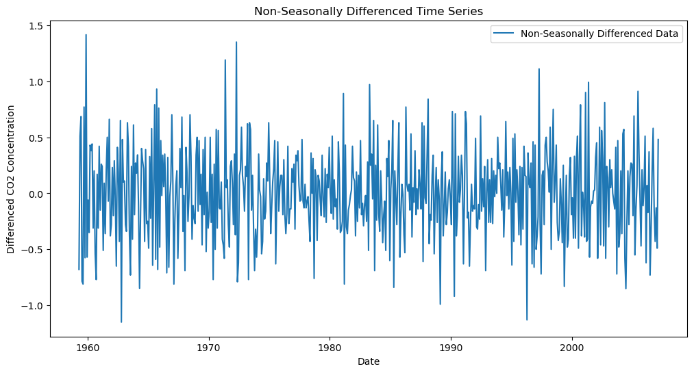

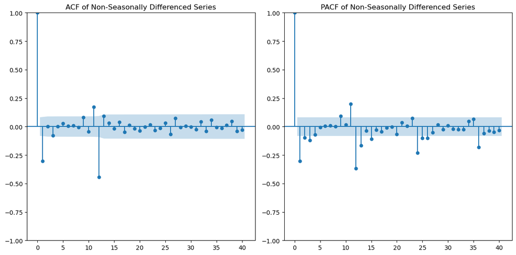

```
(ADF Statistic    -9.123388e+00
 p-value           3.160769e-15
 # Lags Used       1.400000e+01
 # Observations    5.600000e+02
 dtype: float64,
 KPSS Statistic     0.02129
 p-value            0.10000
 Lags Used         25.00000
 dtype: float64)
```

```python
# Importing the necessary function
from statsmodels.graphics.tsaplots import plot_acf, plot_pacf
# Apply non-seasonal differencing
train['non_seasonal_diff'] = seasonal_diff.diff().dropna()

# Plotting the non-seasonally differenced data
plt.figure(figsize=(12, 6))
plt.plot(train['non_seasonal_diff'].dropna(), label='Non-Seasonally Differenced Data')
plt.xlabel('Date')
plt.ylabel('Differenced CO2 Concentration')
plt.title('Non-Seasonally Differenced Time Series')
plt.legend()
plt.show()

# ADF test on non-seasonally differenced data
adf_result_non_seasonal = adfuller(train['non_seasonal_diff'].dropna())
adf_output_non_seasonal = pd.Series(adf_result_non_seasonal[0:4], index=['ADF Statistic', 'p-value', '# Lags Used', '# Observations'])

# KPSS test on non-seaonally differenced data
kpss_result_non_seasonal = kpss(train['non_seasonal_diff'].dropna(), regression='c', nlags='auto')
kpss_output_non_seasonal = pd.Series(kpss_result_non_seasonal[0:3], index=['KPSS Statistic', 'p-value', 'Lags Used'])

# Plotting ACF and PACF
plt.figure(figsize=(12, 6))

plt.subplot(121)
plot_acf(train['non_seasonal_diff'].dropna(), lags=40, ax=plt.gca())
plt.title('ACF of Non-Seasonally Differenced Series')

plt.subplot(122)
plot_pacf(train['non_seasonal_diff'].dropna(), lags=40, ax=plt.gca())
plt.title('PACF of Non-Seasonally Differenced Series')

plt.tight_layout()
plt.show()

adf_output_non_seasonal, kpss_output_non_seasonal
```

C) 6 pts Fit and predict a SARIMA model using your best estimate of the SARIMA(p,d,q)(P,D,Q)m order. Return the model summary

```python
from statsmodels.tsa.statespace.sarimax import SARIMAX

# Fitting the SARIMA model
sarima_model = SARIMAX(train['co2'], order=(1, 1, 1), seasonal_order=(1, 1, 1, 12)).fit()

# Model summary
sarima_model_summary = sarima_model.summary()
print(sarima_model_summary)
```

```
                                     SARIMAX Results
==========================================================================================
Dep. Variable:                                co2   No. Observations:                  588
Model:             SARIMAX(1, 1, 1)x(1, 1, 1, 12)   Log Likelihood                -122.092
Date:                            Thu, 11 Jul 2024   AIC                            254.184
Time:                                    20:24:12   BIC                            275.955
Sample:                                         0   HQIC                           262.675
                                            - 588
Covariance Type:                              opg
==============================================================================
                 coef    std err          z      P>|z|      [0.025      0.975]
------------------------------------------------------------------------------
ar.L1          0.2062      0.105      1.962      0.050       0.000       0.412
ma.L1         -0.5380      0.094     -5.715      0.000      -0.723      -0.354
ar.S.L12       0.0179      0.049      0.368      0.713      -0.078       0.114
ma.S.L12      -0.8641      0.029    -29.724      0.000      -0.921      -0.807
sigma2         0.0870      0.005     16.651      0.000       0.077       0.097
===================================================================================
Ljung-Box (L1) (Q):                   0.10   Jarque-Bera (JB):                 0.15
Prob(Q):                              0.75   Prob(JB):                         0.93
Heteroskedasticity (H):               0.90   Skew:                            -0.04
Prob(H) (two-sided):                  0.47   Kurtosis:                         2.97
===================================================================================

Warnings:
[1] Covariance matrix calculated using the outer product of gradients (complex-step).
```

D) 6 pts Examine the residuals. Include the following: plot, histogram, ACF, Ljung Box results

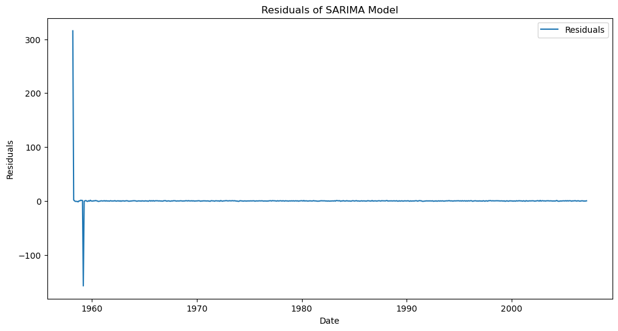

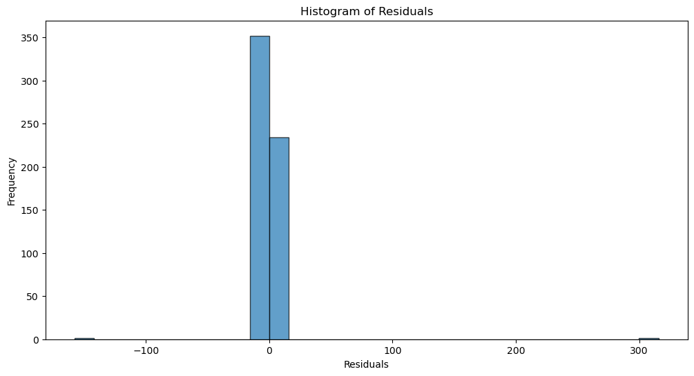

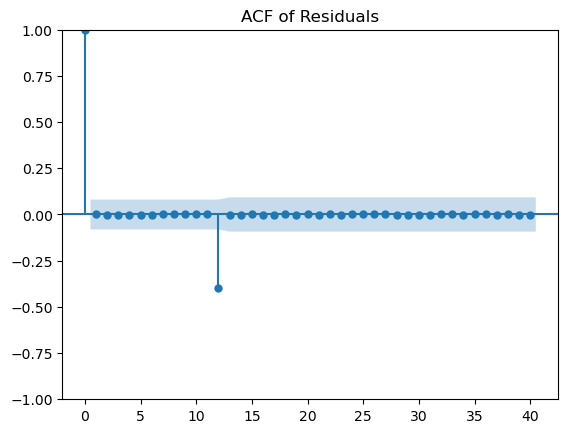

```
      lb_stat     lb_pvalue
20  96.348718  5.638207e-12
```

```python
# Residuals analysis
residuals = sarima_model.resid

# Plotting residuals
plt.figure(figsize=(12, 6))
plt.plot(residuals, label='Residuals')
plt.xlabel('Date')
plt.ylabel('Residuals')
plt.title('Residuals of SARIMA Model')
plt.legend()
plt.show()

# Histogram of residuals
plt.figure(figsize=(12, 6))
plt.hist(residuals, bins=30, edgecolor='k', alpha=0.7)
plt.xlabel('Residuals')
plt.ylabel('Frequency')
plt.title('Histogram of Residuals')
plt.show()

# ACF of residuals
plt.figure(figsize=(12, 6))
plot_acf(residuals, lags=40)
plt.title('ACF of Residuals')
plt.show()

# Ljung-Box test
ljung_box_result = acorr_ljungbox(residuals, lags=[20], return_df=True)
print(ljung_box_result)
```

# E) 6 pts Predict the test set. Include the following: MAE, MSE, MAPE, sMAPE, MASE. Can use prebuilt functions or calculate by hand.

```python
import numpy as np
import pandas as pd

# Forecasting the test set
forecast = sarima_model.get_forecast(steps=len(test))
forecasted_values = forecast.predicted_mean

# Resetting index of the test set to ensure proper alignment
test_reset = test.reset_index(drop=True)

# Recalculating the performance metrics
mae = np.mean(np.abs(forecasted_values.values - test_reset['co2'].values))
mse = np.mean((forecasted_values.values - test_reset['co2'].values)**2)
mape = np.mean(np.abs((forecasted_values.values - test_reset['co2'].values) / test_reset['co2'].values)) * 100
smape = 100 / len(test_reset['co2']) * np.sum(2 * np.abs(forecasted_values.values - test_reset['co2'].values) / (np.abs(test_reset['co2'].values) + np.abs(forecasted_values.values)))

# MASE
naive_forecast = train['co2'].shift(1).dropna()
mase = np.mean(np.abs(forecasted_values.values - test_reset['co2'].values)) / np.mean(np.abs(naive_forecast - train['co2'].iloc[1:]))

print('MAE:', mae)
print('MSE:', mse)
print('MAPE:', mape)
print('sMAPE:', smape)
print('MASE:', mase)
```

```
MAE: 2.091250233813033
MSE: 7.4594484803177314
MAPE: 0.5189022265989818
sMAPE: 0.5211721781988826
MASE: 1.9303443574736996
```

# Part 3. 30 pts – Auto ARIMA – need to use pmdarima in order to examine residuals

A) 6 pts Fit using auto_arima(), you may need to provide the differencing orders.

```python
!pip install pmdarima
```

```python
from pmdarima import auto_arima
auto_arima_model = auto_arima(train['co2'], seasonal=True, m=12, trace=True, error_action='ignore', suppress_warnings=True)
```

```
Performing stepwise search to minimize aic
 ARIMA(2,1,2)(1,0,1)[12] intercept   : AIC=320.541, Time=1.49 sec
 ARIMA(0,1,0)(0,0,0)[12] intercept   : AIC=1899.963, Time=0.02 sec
 ARIMA(1,1,0)(1,0,0)[12] intercept   : AIC=inf, Time=0.42 sec
 ARIMA(0,1,1)(0,0,1)[12] intercept   : AIC=1266.913, Time=0.21 sec
 ARIMA(0,1,0)(0,0,0)[12]             : AIC=1903.263, Time=0.01 sec
 ARIMA(2,1,2)(0,0,1)[12] intercept   : AIC=inf, Time=1.23 sec
 ARIMA(2,1,2)(1,0,0)[12] intercept   : AIC=556.443, Time=1.48 sec
 ARIMA(2,1,2)(2,0,1)[12] intercept   : AIC=340.878, Time=3.36 sec
 ARIMA(2,1,2)(1,0,2)[12] intercept   : AIC=364.179, Time=3.66 sec
 ARIMA(2,1,2)(0,0,0)[12] intercept   : AIC=1144.569, Time=0.33 sec
 ARIMA(2,1,2)(0,0,2)[12] intercept   : AIC=inf, Time=3.17 sec
 ARIMA(2,1,2)(2,0,0)[12] intercept   : AIC=440.887, Time=3.75 sec
 ARIMA(2,1,2)(2,0,2)[12] intercept   : AIC=338.933, Time=4.28 sec
 ARIMA(1,1,2)(1,0,1)[12] intercept   : AIC=322.443, Time=1.27 sec
 ARIMA(2,1,1)(1,0,1)[12] intercept   : AIC=334.754, Time=1.04 sec
 ARIMA(3,1,2)(1,0,1)[12] intercept   : AIC=322.238, Time=1.56 sec
 ARIMA(2,1,3)(1,0,1)[12] intercept   : AIC=322.236, Time=1.72 sec
 ARIMA(1,1,1)(1,0,1)[12] intercept   : AIC=320.325, Time=1.10 sec
 ARIMA(1,1,1)(0,0,1)[12] intercept   : AIC=1211.461, Time=0.23 sec
 ARIMA(1,1,1)(1,0,0)[12] intercept   : AIC=572.495, Time=0.79 sec
 ARIMA(1,1,1)(2,0,1)[12] intercept   : AIC=324.734, Time=2.67 sec
 ARIMA(1,1,1)(1,0,2)[12] intercept   : AIC=333.777, Time=2.58 sec
 ARIMA(1,1,1)(0,0,0)[12] intercept   : AIC=1423.061, Time=0.07 sec
 ARIMA(1,1,1)(0,0,2)[12] intercept   : AIC=1069.538, Time=0.80 sec
 ARIMA(1,1,1)(2,0,0)[12] intercept   : AIC=444.510, Time=1.72 sec
 ARIMA(1,1,1)(2,0,2)[12] intercept   : AIC=305.691, Time=2.97 sec
 ARIMA(0,1,1)(2,0,2)[12] intercept   : AIC=306.497, Time=2.98 sec
 ARIMA(1,1,0)(2,0,2)[12] intercept   : AIC=314.440, Time=2.75 sec
 ARIMA(2,1,1)(2,0,2)[12] intercept   : AIC=386.471, Time=3.73 sec
 ARIMA(1,1,2)(2,0,2)[12] intercept   : AIC=307.791, Time=3.43 sec
 ARIMA(0,1,0)(2,0,2)[12] intercept   : AIC=354.574, Time=2.49 sec
 ARIMA(0,1,2)(2,0,2)[12] intercept   : AIC=307.607, Time=3.02 sec
 ARIMA(2,1,0)(2,0,2)[12] intercept   : AIC=313.124, Time=2.75 sec
 ARIMA(1,1,1)(2,0,2)[12]             : AIC=302.082, Time=2.51 sec
 ARIMA(1,1,1)(1,0,2)[12]             : AIC=300.221, Time=2.46 sec
 ARIMA(1,1,1)(0,0,2)[12]             : AIC=1069.201, Time=0.51 sec
 ARIMA(1,1,1)(1,0,1)[12]             : AIC=298.366, Time=0.93 sec
 ARIMA(1,1,1)(0,0,1)[12]             : AIC=1211.067, Time=0.15 sec
 ARIMA(1,1,1)(1,0,0)[12]             : AIC=570.803, Time=0.29 sec
 ARIMA(1,1,1)(2,0,1)[12]             : AIC=300.242, Time=1.88 sec
 ARIMA(1,1,1)(0,0,0)[12]             : AIC=1422.488, Time=0.05 sec
 ARIMA(1,1,1)(2,0,0)[12]             : AIC=442.778, Time=0.90 sec
 ARIMA(0,1,1)(1,0,1)[12]             : AIC=299.381, Time=0.73 sec
 ARIMA(1,1,0)(1,0,1)[12]             : AIC=307.405, Time=0.85 sec
 ARIMA(2,1,1)(1,0,1)[12]             : AIC=298.554, Time=1.12 sec
 ARIMA(1,1,2)(1,0,1)[12]             : AIC=inf, Time=nan sec
 ARIMA(0,1,0)(1,0,1)[12]             : AIC=inf, Time=0.50 sec
 ARIMA(0,1,2)(1,0,1)[12]             : AIC=299.565, Time=0.93 sec
 ARIMA(2,1,0)(1,0,1)[12]             : AIC=305.024, Time=1.17 sec
 ARIMA(2,1,2)(1,0,1)[12]             : AIC=303.114, Time=1.48 sec

Best model:  ARIMA(1,1,1)(1,0,1)[12]
Total fit time: 80.472 seconds
```

B) 6 pts Return the model summary

```python
print(auto_arima_model.summary())
```

```
                                     SARIMAX Results
==========================================================================================
Dep. Variable:                                  y   No. Observations:                  588
Model:             SARIMAX(1, 1, 1)x(1, 0, 1, 12)   Log Likelihood                -144.183
Date:                            Thu, 11 Jul 2024   AIC                            298.366
Time:                                    20:25:19   BIC                            320.241
Sample:                                         0   HQIC                           306.890
                                            - 588
Covariance Type:                              opg
==============================================================================
                 coef    std err          z      P>|z|      [0.025      0.975]
------------------------------------------------------------------------------
ar.L1          0.2506      0.092      2.726      0.006       0.070       0.431
ma.L1         -0.5629      0.084     -6.663      0.000      -0.729      -0.397
ar.S.L12       0.9996      0.000   2994.321      0.000       0.999       1.000
ma.S.L12      -0.8613      0.026    -33.049      0.000      -0.912      -0.810
sigma2         0.0871      0.005     16.557      0.000       0.077       0.097
===================================================================================
Ljung-Box (L1) (Q):                   0.22   Jarque-Bera (JB):                 0.17
Prob(Q):                              0.64   Prob(JB):                         0.92
Heteroskedasticity (H):               0.90   Skew:                            -0.04
Prob(H) (two-sided):                  0.45   Kurtosis:                         2.97
===================================================================================

Warnings:
[1] Covariance matrix calculated using the outer product of gradients (complex-step).
```

3C) pts Examine the residuals. Include the following: plot, histogram, ACF, Ljung Box results

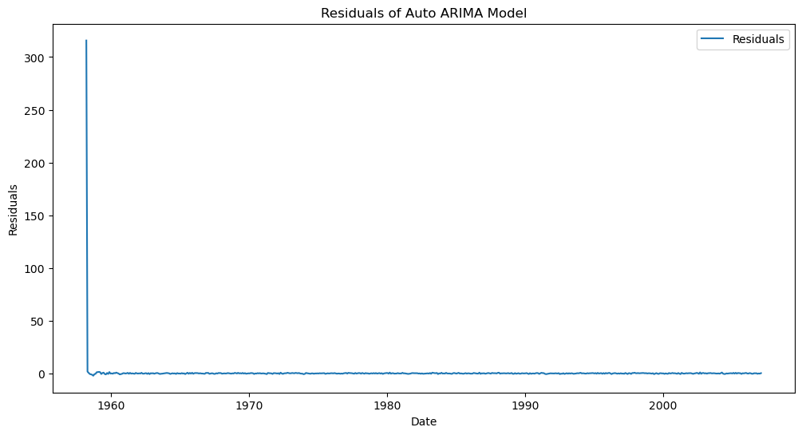

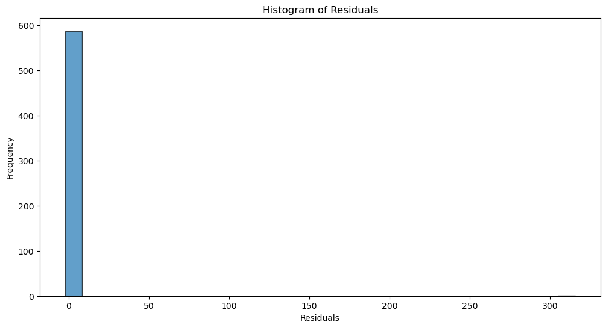

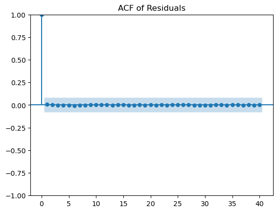

```
     lb_stat  lb_pvalue
20  0.135217        1.0
```

```python
import numpy as np
import pandas as pd
import matplotlib.pyplot as plt
from pmdarima import auto_arima
from statsmodels.graphics.tsaplots import plot_acf
from statsmodels.stats.diagnostic import acorr_ljungbox
from sklearn.metrics import mean_absolute_error, mean_squared_error


# Residuals analysis
residuals = auto_arima_model.resid()

# Plotting residuals
plt.figure(figsize=(12, 6))
plt.plot(residuals, label='Residuals')
plt.xlabel('Date')
plt.ylabel('Residuals')
plt.title('Residuals of Auto ARIMA Model')
plt.legend()
plt.show()

# Histogram of residuals
plt.figure(figsize=(12, 6))
plt.hist(residuals, bins=30, edgecolor='k', alpha=0.7)
plt.xlabel('Residuals')
plt.ylabel('Frequency')
plt.title('Histogram of Residuals')
plt.show()

# ACF of residuals
plt.figure(figsize=(12, 6))
plot_acf(residuals, lags=40)
plt.title('ACF of Residuals')
plt.show()

# Ljung-Box test
ljung_box_result = acorr_ljungbox(residuals, lags=[20], return_df=True)
print(ljung_box_result)
```

3D) 6 pts Predict the test set. Include the following: MAE, MSE, MAPE, sMAPE, MASE. Can use prebuilt functions or calculate by hand.

```python
import numpy as np
import pandas as pd
from pmdarima import auto_arima
from statsmodels.graphics.tsaplots import plot_acf
from sklearn.metrics import mean_absolute_error, mean_squared_error
# Forecasting the test set
forecast_auto_arima = auto_arima_model.predict(n_periods=len(test))

# Reseting index of the test set to ensure proper alignment
test_reset = test.reset_index(drop=True)

# Converting forecasted values to DataFrame and reset index
forecast_auto_arima_df = pd.DataFrame(forecast_auto_arima, columns=['forecast']).reset_index(drop=True)

# Ensuring the length of forecasted values matches the test set
print("Length of Forecasted Values:", len(forecast_auto_arima_df))
print("Length of Test Set:", len(test_reset['co2']))

# Calculating performance metrics
mae_auto_arima = mean_absolute_error(test_reset['co2'], forecast_auto_arima_df['forecast'])
mse_auto_arima = mean_squared_error(test_reset['co2'], forecast_auto_arima_df['forecast'])
mape_auto_arima = np.mean(np.abs((test_reset['co2'] - forecast_auto_arima_df['forecast']) / test_reset['co2'])) * 100
smape_auto_arima = 100 / len(test_reset['co2']) * np.sum(2 * np.abs(forecast_auto_arima_df['forecast'] - test_reset['co2']) / (np.abs(test_reset['co2']) + np.abs(forecast_auto_arima_df['forecast'])))

# Calculating MASE manually
naive_forecast = train['co2'].shift(1).dropna().values
train_values = train['co2'].iloc[1:].values  # Align the train values for MASE calculation
mase_auto_arima = np.mean(np.abs(forecast_auto_arima_df['forecast'] - test_reset['co2'])) / np.mean(np.abs(naive_forecast - train_values))

# Comparing with SARIMA results
print('SARIMA Model Performance:')
print('MAE:', mae)
print('MSE:', mse)
print('MAPE:', mape)
print('sMAPE:', smape)
print('MASE:', mase)

print('Auto ARIMA Model Performance:')
print('MAE (Auto ARIMA):', mae_auto_arima)
print('MSE (Auto ARIMA):', mse_auto_arima)
print('MAPE (Auto ARIMA):', mape_auto_arima)
print('sMAPE (Auto ARIMA):', smape_auto_arima)
print('MASE (Auto ARIMA):', mase_auto_arima)
```

```
Length of Forecasted Values: 147
Length of Test Set: 147
SARIMA Model Performance:
MAE: 2.091250233813033
MSE: 7.4594484803177314
MAPE: 0.5189022265989818
sMAPE: 0.5211721781988826
MASE: 1.9303443574736996
Auto ARIMA Model Performance:
MAE (Auto ARIMA): 2.0973579817165526
MSE (Auto ARIMA): 7.526732407097637
MAPE (Auto ARIMA): 0.5203731568546999
sMAPE (Auto ARIMA): 0.5226632297625078
MASE (Auto ARIMA): 1.9359821604069878
```

3E) 6 pts Summarize the difference between your SARIMA and the Auto Arima models. Compare order, performance on training data, performance on test data. Which model would you go forward with?

Model Orders SARIMA Model (p,d, q) = (1,1,1) and (P,D,Q,m) = (1,1,1,12) Auto ARIMA model (p,d,q) = (1,1,1) and (P, D, Q, m) = (1,0,1,12)

Model performance on training data: Metric SARIMA Auto ARIMA Log Likelihood -122.092 -144.183 AIC 254.184 298.366 BIC 275.955 320.241

On Test Data

Metric SARIMA Auto ARIMA MAE 2.091 2.097 MSE 7.459 7.527 MAPE 0.519% 0.520% sMAPE 0.521% 0.523% MASE 1.930 1.936

Based on the performance metrics on the test data, I would go forward with SARIMA model. The SARIMA model shows slighly better performance on the test data.

# Part 4. 30 pts – Recursive method with best model

A. 10 pts Create your own function or class to perform a different method of recursive forecasting. Can use any other recursive method, here is a paper for inspiration, not limitation: https://arxiv.org/pdf/1108.3259.pdf

```python
import numpy as np
import pandas as pd
from sklearn.preprocessing import MinMaxScaler
import tensorflow as tf
from tensorflow.keras.models import Sequential
from tensorflow.keras.layers import LSTM, Dense, Dropout
from sklearn.metrics import mean_absolute_error, mean_squared_error

# Normalize the numerical data
scaler = MinMaxScaler()
scaled_data = scaler.fit_transform(data['co2'].values.reshape(-1, 1))

# Function to create sequences
def create_sequences(data, seq_length):
    xs, ys = [], []
    for i in range(len(data) - seq_length):
        x = data[i:i + seq_length]
        y = data[i + seq_length]
        xs.append(x)
        ys.append(y)
    return np.array(xs), np.array(ys)

seq_length = 12
X, y = create_sequences(scaled_data, seq_length)

# Reshaping X to be 3D for LSTM input (samples, timesteps, features)
X = X.reshape((X.shape[0], X.shape[1], 1))

# Splitting the data into training and testing sets
train_size = int(len(X) * 0.8)
X_train, X_test = X[:train_size], X[train_size:]
y_train, y_test = y[:train_size], y[train_size:]

# Building the LSTM model
model = Sequential()
model.add(LSTM(100, activation='relu', input_shape=(seq_length, 1), return_sequences=True))
model.add(Dropout(0.2))
model.add(LSTM(100, activation='relu'))
model.add(Dropout(0.2))
model.add(Dense(1))
model.compile(optimizer='adam', loss='mse')

# Training the model
history = model.fit(X_train, y_train, epochs=50, batch_size=32, validation_split=0.2)

def dirrec_forecasting(model, X_test, n_steps):
    forecasts = []
    current_input = X_test[0]
    for i in range(n_steps):
        current_input_reshaped = current_input[np.newaxis, :, :]
        prediction = model.predict(current_input_reshaped)[0, 0]
        forecasts.append(prediction)
        current_input = np.append(current_input[1:], prediction).reshape((seq_length, 1))
    return np.array(forecasts)

# Performing recursive forecasting
n_steps = len(y_test)
forecasts = dirrec_forecasting(model, X_test, n_steps)

# Inversing scale the forecasts
forecasts = scaler.inverse_transform(forecasts.reshape(-1, 1))

# Comparing with actual values
y_test_actual = scaler.inverse_transform(y_test.reshape(-1, 1))
```

[output not shown]

[output cut: 140 more lines]

[output not shown]

4B) 10 pts Include the following: MAE, MSE, MAPE, sMAPE, MASE. Can use prebuilt functions or calculate by hand.

```python
# Calculate performance metrics
mae = mean_absolute_error(y_test_actual, forecasts)
mse = mean_squared_error(y_test_actual, forecasts)
mape = np.mean(np.abs((y_test_actual - forecasts) / y_test_actual)) * 100
smape = 100 / len(y_test_actual) * np.sum(2 * np.abs(forecasts - y_test_actual) / (np.abs(y_test_actual) + np.abs(forecasts)))
mase = mae / np.mean(np.abs(y_train - np.mean(y_train)))

print('MAE:', mae)
print('MSE:', mse)
print('MAPE:', mape)
print('sMAPE:', smape)
print('MASE:', mase)
```

```
MAE: 15.884894893251618
MSE: 337.9586750402242
MAPE: 3.957950688407419
sMAPE: 4.064611794439236
MASE: 93.37397000658001
```

4C) 10 pts Summarize the difference between your Recursive forecasts and your h-step ahead forecasts from SARIMA and Auto ARIMA. Explain the methodologies and the reason that you get different results. What are the advantages and disadvantages of the recursive method.

The difference between the recursive forecasts using LSTM and the h-step ahead forecasts from SARIMA and Auto ARIMA can be explained as discussed in the paper “A review and comparison of strategies for multi-step ahead forecasting in time series” (Ben Taieb et al., 2012). Recursive forecasting with LSTM involves predicting one time step ahead and using that prediction as input for the next step, following a recursive strategy. This method is dynamic and flexible, capable of capturing complex non-linear relationships within the data, but it can lead to error propagation where inaccuracies in early predictions compound in subsequent steps.

This is evident in the higher error metrics observed: MAE of 15.885, MSE of 337.958, MAPE of 3.95, and sMAPE of 4.06%. On the other hand, SARIMA and Auto ARIMA generate h-step ahead forecasts directly, similar to the direct strategy discussed in the paper, where forecasts for future steps are made in a single model run without using previous predictions as inputs. These models assume linearity and seasonality in the data, providing significantly lower error metrics and better performance on the test data.

The paper highlights that while the recursive approach can adapt to changing data patterns and model complex relationships, it is prone to error accumulation. Conversely, the direct approach, akin to SARIMA and Auto ARIMA, avoids this issue by predicting future values in one step, leading to more stable and accurate forecasts. The primary advantage of the recursive method is its flexibility and ability to model non-linear time series, making it useful in capturing intricate data patterns. However, its disadvantages include increased computational complexity, a higher risk of overfitting, and vulnerability to error propagation. SARIMA and Auto ARIMA, using a more traditional direct strategy, are more robust and interpretable for linear and seasonal data patterns, providing more reliable and accurate forecasts without the iterative error accumulation seen in the recursive approach.